# Exame_Prático

Diogo Alexandre Alonso De Freitas

2022-11-03

##### Dados Iniciais

```r
nreplica <- 104841
pe_a <- 1
pe_b <- 4
pe_c <- 8

npac <- 104841%%2000
nvis <- ceiling(nreplica*1.5)
```

##### Enunciado

Devido às condições económicas de um determinado país, onde a subida de preços está a retirar poder de compra às famílias, uma determinada associação conseguiu angariar o apoio de três grandes grupos de distribuição (A, B e C) para fornecimento de frescos (a integrar cabazes básicos que serão entregues pela associação às famílias do programa de apoio).

Um dos voluntários está encarregue de monitorizar a qualidade dos pacotes de produtos frescos entregues, e classifica os pacotes de produtos em duas categorias: 1 - para entrega às famílias e 0 - para compostagem.

Assim, cada pacote pode ser classificado segundo duas vertentes: Origem (A, B ou C) e Estado (1 ou 0).

Considere então a experiência aleatória que consiste em observar um pacote de frescos e proceder a esta dupla classificação (origem, estado).

#### 1.a)

```r
Origem <- c("A","B","C")
Estado <- c(1,2)

Origem_Estado <- expand.grid("Origem"=Origem,"Estado"=Estado)
Origem_Estado
```

| Origem | Estado |
| --- | --- |
| A | 1 |
| B | 1 |
| C | 1 |
| A | 2 |
| B | 2 |
| C | 2 |

#### 1.b)

```r
Prob = c((1-pe_a/100)*0.2, (1-pe_b/100)*0.4, (1-pe_c/100)*0.4, (pe_a/100)*0.2, (pe_b/100)*0.4, (pe_c/100)*0.4)
Origem_Estado <- data.frame(Origem_Estado, "Prob" = Prob)
Origem_Estado
```

| Origem | Estado | Prob |
| --- | --- | --- |
| A | 1 | 0.198 |
| B | 1 | 0.384 |
| C | 1 | 0.368 |
| A | 2 | 0.002 |
| B | 2 | 0.016 |
| C | 2 | 0.032 |

#### 1.c)

```r
rbinom(length(Origem_Estado),20,Prob)
```

```
## [1] 4 7 7
```

## GRUPO B (6 valores)

Uma determinada empresa é especialista na recolha de preços. Esta empresa recolhe preços e tem dois serviços principais: divulgação de preços para comparações online e fornecimento de pacotes de preços a especialistas que analisam a inflação.

Para a divulgação de preços para comparações online, a empresa usa um site.

Sabe-se que o valor que a empresa recebe, em euros, por cada visita ao site segue uma distribuição normal com valor médio 0.5 € e variância 0.2.

Já relativamente aos pacotes de preços fornecidos a especialistas, a empresa sabe que o valor que recebe por cada pacote fornecido, em euros, segue uma distribuição normal de valor médio 500 e variância 100.

Considere que em certo mês, m, a empresa tem **nvis** visitas e vende **npac** pacotes de preços.

### a. Calcule os parâmetros caracterizadores da variável Xm – valor recebido no mês m. Represente graficamente a função densidade de Xm.

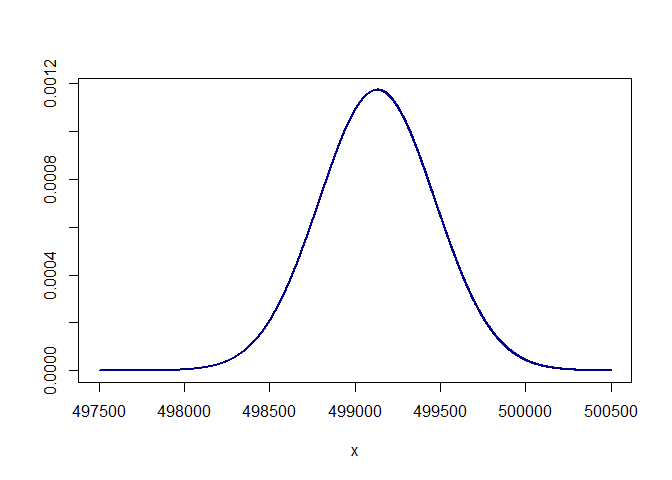

```r
Site <- c(0.5*nvis, sqrt(0.2)*sqrt(nvis))
Pacote <- c(500*npac, sqrt(100)*sqrt(npac))

Xm <- c(Site[1]+Pacote[1], sqrt(Site[2]^2 + Pacote[2]^2))

x <- (497500:500500)
# dnorm(x, mean = Xm[1], sd = Xm[2])
plot(x, dnorm(x, mean=Xm[1], sd=Xm[2]), type = "l", ylab = "", lwd = 2, col = "darkblue")
```

### b. Calcule o quantil de probabilidade 0.9 dessa distribuição. Represente a área em causa no gráfico.

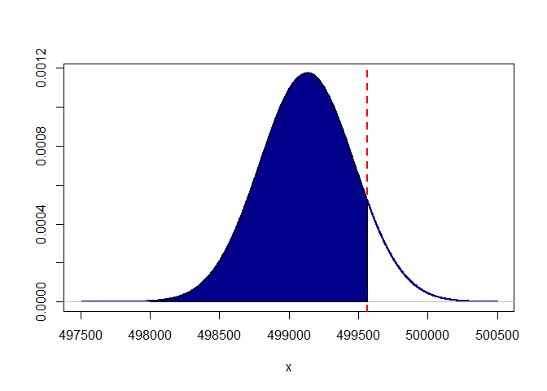

```r
eixo_x<-c(497500,500500)
eixo_y<-c(0,dnorm(0))

plot(x, dnorm(x, mean=Xm[1], sd=Xm[2]), type = "l", ylab = "", lwd = 2, col = "darkblue")

# Add x and y-axis lines
abline(h = 0, col="grey")
abline(v = 0, col = "black", lty=2, lwd=2)
abline(v = qnorm(0.9, mean = Xm[1], sd = Xm[2]), col = "red", lty=2, lwd=2)

#marcar a área

x1 <- seq(498000,qnorm(0.9, mean = Xm[1], sd = Xm[2]),0.01)
y1 <- dnorm(x1, mean=Xm[1], sd=Xm[2])

coord_x <- c(498000,x1,qnorm(0.9, mean = Xm[1], sd = Xm[2]))
coord_y <- c(0,y1,0)
polygon(coord_x,coord_y,col='blue4')
```

### c. Gere **nreplica** observações aleatórias da variável Xm e use essa simulação para obter um valor aproximado para o quantil referido na alínea anterior.

```r
y_replica <- rnorm(nreplica, mean = Xm[1], sd = Xm[2])
quantile(y_replica, 0.9)
```

```
##      90%
## 499568.4
```